# Dragon Ball Supervised Learning Classification

## Problem Definition

Can we accurately predict whether a Dragon Ball character will win or lose a fight based on their attributes such as Power Level, Race, Transformations, Techniques, and Previous Battles?

### Context

- In the Dragon Ball universe, battles are determined by various factors, including a fighter’s power level, race, transformations, fighting techniques, and experience.
- Using machine learning classification models, we can estimate the probability of winning based on these attributes.
- This could be useful for game balancing, AI-driven character matchups, competitive strategy analysis, and fan discussions.

## Importing Libraries and the Dataset

```python
# Mounting the drive
from google.colab import drive
drive.mount('/content/drive')
```

```python
# Used to ignore the warning given as output of the code
import warnings                                       # Ignore the warning given as output of the code
warnings.filterwarnings('ignore')

# Basic libraries of python for numeric and dataframe computations
import numpy as np                                    # Basic libraries numeric and dataframe computations
import pandas as pd

# Import Matplotlib the Basic library for data visualization
# Import seaborn - Slightly advanced library for data visualization
import matplotlib.pyplot as plt                       # Basic visualization library
import seaborn as sns

# Import the required library to compute the cosine similarity between two vectors


# Import defaultdict from collections A dictionary output that does not raise a key error
from collections import defaultdict                   # A dictionary output that does not raise a key error
```

## Load the Dataset

```python
# Loading the ratings dataset
data = pd.read_csv('/content/drive/MyDrive/My DS DA/Dragon Ball Z/data.csv')
```

## Data Overview

```python
data.sample(5)
```

|  | Name | Race | Gender | Power Level | Ki Blast | Melee Combat | Speed | Special Attack | Transformation | Speed_Original | Normalized_Power | Power_Score | Meta |
| --- | --- | --- | --- | --- | --- | --- | --- | --- | --- | --- | --- | --- | --- |
| 51 | Janemba | Demon | Male | 20000 | Bunkai Teleport | Rakshasa's Claw | 3 | Dimension Sword | Transformation | Fast | 0.10 | 0.97 | Janemba Demon Bunkai Teleport Rakshasa's Claw ... |
| 13 | Cell | Bio-Android | Male | 10000 | Kamehameha | Cell Smash | 3 | Solar Kamehameha | Perfect Form | Fast | 0.05 | 0.93 | Cell Bio-Android Kamehameha Cell Smash Solar K... |
| 21 | Ox-King | Human | Male | 700 | NaN | Axe Handle Smash | 1 | Fireball | - | Slow | 0.00 | 0.30 | Ox-King Human nan Axe Handle Smash Fireball - ... |
| 35 | Nappa | Saiyan | Male | 4000 | Bomber DX | Arm Break | 2 | Break Cannon | - | Average | 0.02 | 0.61 | Nappa Saiyan Bomber DX Arm Break Break Cannon ... |
| 17 | Spopovich | Human | Male | 1100 | Energy Wave | Brutal Strikes | 2 | - | Majin Form | Average | 0.01 | 0.60 | Spopovich Human Energy Wave Brutal Strikes - M... |

Check for missing values

```python
data.isnull().sum()
```

|  | 0 |
| --- | --- |
| Name | 0 |
| Race | 0 |
| Gender | 0 |
| Power Level | 0 |
| Ki Blast | 20 |
| Melee Combat | 11 |
| Speed | 0 |
| Special Attack | 31 |
| Transformation | 0 |
| Speed_Original | 0 |
| Normalized_Power | 0 |
| Power_Score | 0 |
| Meta | 0 |

**dtype:** int64

```python
(data.isnull().sum() / data.shape[0])*100
```

|  | 0 |
| --- | --- |
| Name | 0.000000 |
| Race | 0.000000 |
| Gender | 0.000000 |
| Power Level | 0.000000 |
| Ki Blast | 29.411765 |
| Melee Combat | 16.176471 |
| Speed | 0.000000 |
| Special Attack | 45.588235 |
| Transformation | 0.000000 |
| Speed_Original | 0.000000 |
| Normalized_Power | 0.000000 |
| Power_Score | 0.000000 |
| Meta | 0.000000 |

**dtype:** float64

- mising values in columns are less than 50% and some values may be because characters do not have abilities or transformations.

Check for duplicated rows

```python
data.duplicated().sum()
```

```
0
```

```python
data.info()
```

```
<class 'pandas.core.frame.DataFrame'>
RangeIndex: 68 entries, 0 to 67
Data columns (total 13 columns):
 #   Column            Non-Null Count  Dtype
---  ------            --------------  -----
 0   Name              68 non-null     object
 1   Race              68 non-null     object
 2   Gender            68 non-null     object
 3   Power Level       68 non-null     int64
 4   Ki Blast          48 non-null     object
 5   Melee Combat      57 non-null     object
 6   Speed             68 non-null     int64
 7   Special Attack    37 non-null     object
 8   Transformation    68 non-null     object
 9   Speed_Original    68 non-null     object
 10  Normalized_Power  68 non-null     float64
 11  Power_Score       68 non-null     float64
 12  Meta              68 non-null     object
dtypes: float64(2), int64(2), object(9)
memory usage: 7.0+ KB
```

Number of unique values in each column

```python
data.nunique()
```

|  | 0 |
| --- | --- |
| Name | 68 |
| Race | 17 |
| Gender | 2 |
| Power Level | 36 |
| Ki Blast | 39 |
| Melee Combat | 40 |
| Speed | 3 |
| Special Attack | 36 |
| Transformation | 11 |
| Speed_Original | 3 |
| Normalized_Power | 15 |
| Power_Score | 20 |
| Meta | 68 |

**dtype:** int64

## Data Preprocessing and Feature Engineering

Dropping COlumns

```python
data = data.drop(['Name', 'Meta', 'Gender', 'Normalized_Power', 'Power_Score', 'Speed_Original'], axis = 1)
data.head()
```

|  | Race | Power Level | Ki Blast | Melee Combat | Speed | Special Attack | Transformation |
| --- | --- | --- | --- | --- | --- | --- | --- |
| 0 | Saiyan | 9000 | Kamehameha | Dragon Fist | 3 | Spirit Bomb | Super Saiyan |
| 1 | Saiyan | 8500 | Galick Gun | Big Bang | 3 | Final Flash | Super Saiyan |
| 2 | Namekian | 8000 | Special Beam Cannon | Namekian Punch | 3 | Hellzone Grenade | Fuse with Kami |
| 3 | Half-Saiyan | 7500 | Masenko | Soaring Dragon Strike | 3 | Father-Son Kamehameha | Super Saiyan 2 |
| 4 | Half-Saiyan | 7800 | Burning Attack | Sword Strike | 3 | Heat Dome Attack | Super Saiyan |

Creating Numerical and Categorical Columns

```python
num_cols = ['Speed']

cat_cols = ['Race', 'Ki Blast', 'Melee Combat', 'Special Attack', 'Transformation']
```

## Exploratory Data Analysis

- [EDA](https://colab.research.google.com/drive/11_RHgukIdfJhYBmV1efLdg5AxEUDSQn3?usp=sharing)
- [Unsupervised Learning](https://colab.research.google.com/drive/1CMT8F7UpDIHC7l4nXKm9RJCF3CKiu9lt?usp=sharing)
- [Supervised Learning Regression EDA](https://colab.research.google.com/drive/1Ajn_UUD0WagAUDcXMLbiUYNrRAXAnSSm?usp=sharing)
- [Supervised Learning Regression with Lasso and Ridge](https://colab.research.google.com/drive/1CxChCQxS-7xTKGTyo1hDvFhqY8ka6Kqm?usp=sharing)
- [Supervised Learning Regression Continuous with Decision Trees etc](https://colab.research.google.com/drive/1cK5cDgqx4ICwOxYUL8Fdzyh5PE_pkiJ0?usp=sharing)

### EDA Analysis

```python
num_cols = ['Speed', 'Power Level']

cat_cols = ['Race', 'Ki Blast', 'Melee Combat', 'Special Attack', 'Transformation']
```

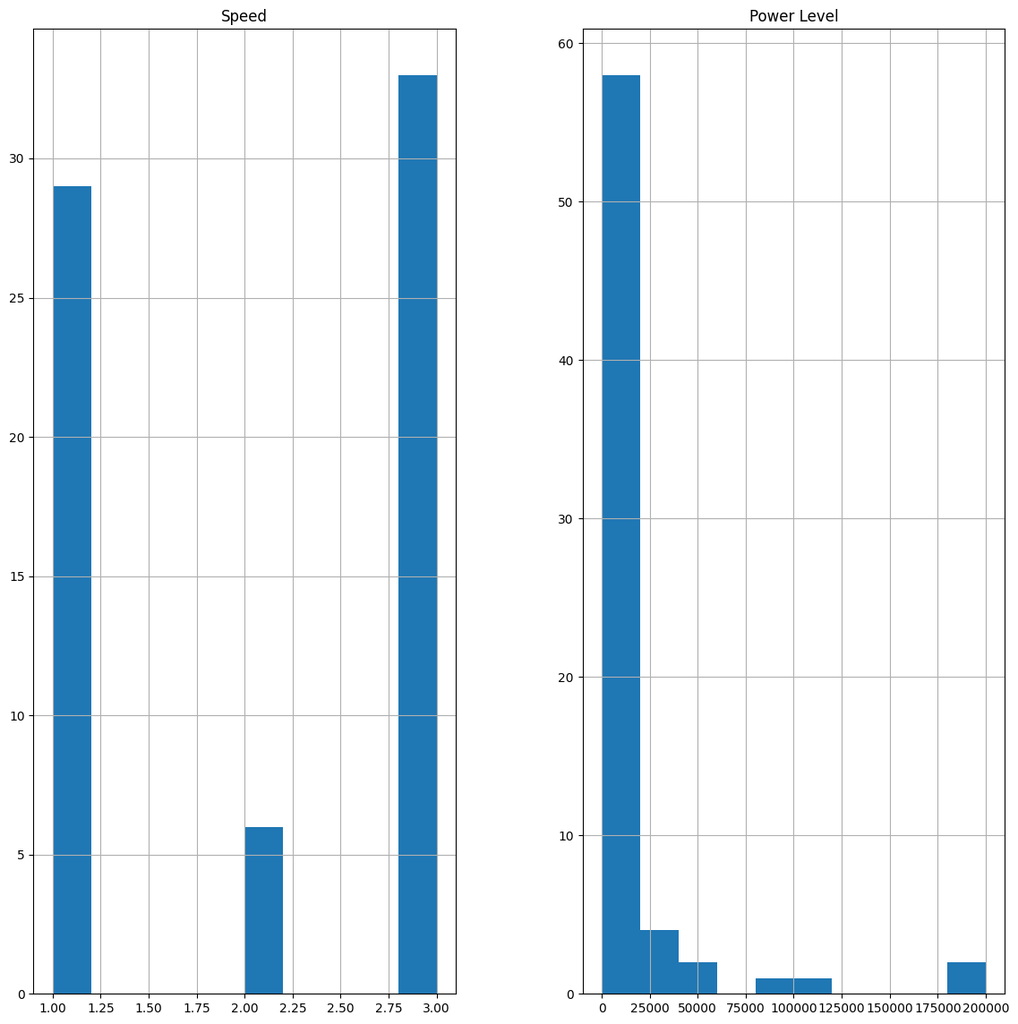

```python
# Creating histograms
data[num_cols].hist(figsize = (14, 14))

plt.show()
```

## Model Building

```python
data.sample(5)
```

|  | Race | Power Level | Ki Blast | Melee Combat | Speed | Special Attack | Transformation |
| --- | --- | --- | --- | --- | --- | --- | --- |
| 53 | Frost Demon | 50000 | Supernova Cooler | Cooler Armored Squadron | 3 | Darkness Eye Beam | Transformation |
| 25 | Human | 5 | NaN | Firearms | 3 | NaN | - |
| 29 | Monkey | 100 | NaN | NaN | 1 | NaN | - |
| 62 | Human | 10 | NaN | NaN | 1 | NaN | - |
| 55 | Android | 8000 | S.S. Deadly Bomber | Android Strikes | 3 | NaN | - |

```python
data.info()
```

```
<class 'pandas.core.frame.DataFrame'>
RangeIndex: 68 entries, 0 to 67
Data columns (total 7 columns):
 #   Column          Non-Null Count  Dtype
---  ------          --------------  -----
 0   Race            68 non-null     object
 1   Power Level     68 non-null     int64
 2   Ki Blast        48 non-null     object
 3   Melee Combat    57 non-null     object
 4   Speed           68 non-null     int64
 5   Special Attack  37 non-null     object
 6   Transformation  68 non-null     object
dtypes: int64(2), object(5)
memory usage: 3.8+ KB
```

### Transformation Column

- some transformations are in progression (e.g., Super Saiyan < Super Saiyan 2 < Final Form)

```python
print(data['Race'].unique())
```

```
['Saiyan' 'Namekian' 'Half-Saiyan' 'Human' 'Android' 'Bio-Android'
 'Frost Demon' 'Majin' 'Demon' 'Shape-shifter' 'Genie' 'Kai' 'Monkey'
 'Grasshopper' 'Alien' 'Wizard' 'Angel']
```

```python
print(data['Transformation'].unique())
```

```
['Super Saiyan' 'Fuse with Kami' 'Super Saiyan 2' '-' 'Perfect Form'
 'Final Form' 'Various Forms' 'Majin Form' 'Merge with Piccolo'
 'Transformation' 'Absorption']
```

Define Transformation Levels

```python
# Define ordinal encoding for transformations
transformation_levels = {
    '-': 0,  # No transformation
    'Super Saiyan': 1,
    'Super Saiyan 2': 2,
    'Final Form': 3,
    'Perfect Form': 4,
    'Majin Form': 4,  # Equivalent to Perfect Form in strength
    'Absorption': 5,
    'Merge with Piccolo': 6,
    'Fuse with Kami': 7,
    'Various Forms': 8  # Miscellaneous transformations
}
```

Apply Encoding

```python
# Apply ordinal encoding to the Transformation column
data['Transformation_Level'] = data['Transformation'].map(transformation_levels)
```

Verify Encoding

```python
print(data[['Transformation', 'Transformation_Level']].drop_duplicates())
```

```
        Transformation  Transformation_Level
0         Super Saiyan                   1.0
2       Fuse with Kami                   7.0
3       Super Saiyan 2                   2.0
5                    -                   0.0
13        Perfect Form                   4.0
14          Final Form                   3.0
15       Various Forms                   8.0
17          Majin Form                   4.0
27  Merge with Piccolo                   6.0
36      Transformation                   NaN
47          Absorption                   5.0
```

Handle Missing Transformations

```python
data['Transformation_Level'].isnull().sum()
```

```
10
```

```python
data['Transformation_Level'] = data['Transformation_Level'].fillna(0)  # Assign lowest level for unknowns
```

Drop the Original Column

```python
data.drop(columns=['Transformation'], inplace=True)
data.sample(5)
```

|  | Race | Power Level | Ki Blast | Melee Combat | Speed | Special Attack | Transformation_Level |
| --- | --- | --- | --- | --- | --- | --- | --- |
| 40 | Alien | 40000 | Recoome Eraser Gun | Recoome Kick | 3 | Recoome Ultra Fighting Bomber | 0.0 |
| 27 | Namekian | 3000 | NaN | NaN | 1 | NaN | 6.0 |
| 39 | Alien | 40000 | Blue Hurricane | Blue Tornado | 3 | Blue Cannonball | 0.0 |
| 13 | Bio-Android | 10000 | Kamehameha | Cell Smash | 3 | Solar Kamehameha | 4.0 |
| 56 | Saiyan | 9000 | Final Explosion | Big Bang Attack | 3 | Final Impact | 4.0 |

### Create Win/Loss Column

Generate All Possible Matchups

```python
from itertools import combinations

# Generate all possible matchups
battle_pairs = list(combinations(data.index, 2))

# Create a DataFrame for battles
battle_df = pd.DataFrame(battle_pairs, columns=['Character_1', 'Character_2'])

# Merge attributes from the original dataset for both characters
battle_df = battle_df.merge(data, left_on='Character_1', right_index=True, suffixes=('_1', ''))
battle_df = battle_df.merge(data, left_on='Character_2', right_index=True, suffixes=('_1', '_2'))

# Assign winner based on power level, speed, and transformation level
battle_df['Winner'] = np.where(
    (battle_df['Power Level_1'] > battle_df['Power Level_2']) |
    ((battle_df['Power Level_1'] == battle_df['Power Level_2']) & (battle_df['Speed_1'] > battle_df['Speed_2'])) |
    ((battle_df['Power Level_1'] == battle_df['Power Level_2']) &
     (battle_df['Speed_1'] == battle_df['Speed_2']) &
     (battle_df['Transformation_Level_1'] > battle_df['Transformation_Level_2'])),
    battle_df['Character_1'],  # Character_1 wins
    battle_df['Character_2']   # Character_2 wins
)
```

Calculate Each Character's Win Rate

```python
# Count wins for each character
win_counts = battle_df['Winner'].value_counts().reset_index()
win_counts.columns = ['Character', 'Wins']

# Count total battles for each character
total_battles = pd.concat([battle_df['Character_1'], battle_df['Character_2']]).value_counts().reset_index()
total_battles.columns = ['Character', 'Total_Battles']

# Merge win counts with total battles
win_loss_stats = total_battles.merge(win_counts, on='Character', how='left').fillna(0)

# Compute win rate
win_loss_stats['Win_Rate'] = win_loss_stats['Wins'] / win_loss_stats['Total_Battles']
win_loss_stats.drop(columns=['Wins'], inplace=True)

# Convert win rate into a binary target: 1 if win rate > 0.5, else 0
win_loss_stats['Win_Loss_Label'] = (win_loss_stats['Win_Rate'] > 0.5).astype(int)
```

Merge Datasets

```python
# Merge win/loss stats into original dataset
data = data.merge(win_loss_stats[['Character', 'Win_Loss_Label']], left_index=True, right_on='Character', how='left')

# Drop redundant 'Character' column after merging (if necessary)
data.drop(columns=['Character'], inplace=True)
```

```python
data.sample(5)
```

|  | Race | Power Level | Ki Blast | Melee Combat | Speed | Special Attack | Transformation_Level | Win_Loss_Label |
| --- | --- | --- | --- | --- | --- | --- | --- | --- |
| 42 | Human | 1800 | Spirit Ball | Wolf Fang Fist | 2 | Wolf Fang Fist | 0.0 | 0 |
| 11 | Alien | 40000 | Recoome Eraser Gun | Recoome Kick | 3 | Recoome Ultra Fighting Bomber | 0.0 | 1 |
| 64 | Monkey | 100 | NaN | NaN | 1 | NaN | 0.0 | 0 |
| 55 | Human | 30 | NaN | Martial Arts | 1 | NaN | 0.0 | 0 |
| 38 | Half-Saiyan | 7500 | Masenko | Soaring Dragon Strike | 3 | Father-Son Kamehameha | 2.0 | 1 |

Creating dummy variables for the categorical variables

```python
# Creating a list of columns for which we will create dummy variables
to_get_dummies_for = ['Race', 'Ki Blast', 'Melee Combat', 'Special Attack']

# Creating dummy variables
data = pd.get_dummies(data = data, columns = to_get_dummies_for, drop_first = True)
```

```python
data.sample(5)
```

|  | Power Level | Speed | Transformation_Level | Win_Loss_Label | Race_Android | Race_Angel | Race_Bio-Android | Race_Demon | Race_Frost Demon | Race_Genie | ... | Special Attack_Recoome Ultra Fighting Bomber | Special Attack_Saiyan Man Pose | Special Attack_Saturday Crush | Special Attack_Solar Flare | Special Attack_Solar Kamehameha | Special Attack_Spirit Bomb | Special Attack_Stone Spit | Special Attack_Supernova | Special Attack_Temporal Do-Over | Special Attack_Wolf Fang Fist |
| --- | --- | --- | --- | --- | --- | --- | --- | --- | --- | --- | --- | --- | --- | --- | --- | --- | --- | --- | --- | --- | --- |
| 3 | 4000 | 3 | 0.0 | 0 | False | False | False | False | False | False | ... | False | False | False | False | False | False | False | False | False | False |
| 15 | 20000 | 3 | 0.0 | 1 | False | False | False | False | False | False | ... | False | False | False | False | False | False | False | False | False | False |
| 4 | 8000 | 3 | 5.0 | 1 | False | False | False | True | False | False | ... | False | False | False | False | False | False | False | False | False | False |
| 55 | 30 | 1 | 0.0 | 0 | False | False | False | False | False | False | ... | False | False | False | False | False | False | False | False | False | False |
| 53 | 300 | 2 | 0.0 | 0 | False | False | False | False | False | False | ... | False | False | False | False | False | False | False | False | False | False |

5 rows × 132 columns

```python
data.isnull().sum().sum()
```

```
0
```

```python
data.duplicated().sum()
```

```
3
```

```python
data = data.drop_duplicates()
```

```python
data.duplicated().sum()
```

```
0
```

Separating the independent variables (X) and the dependent variable (Y)

```python
# Separating the target variable and other variables
Y = data['Win_Loss_Label']
X = data.drop(columns = ['Win_Loss_Label']) #target
```

```python
# data.columns.to_list()
```

## Splitting the data into 80% train and 20% test sets

```python
from sklearn.model_selection import train_test_split


# Splitting the data
x_train, x_test, y_train, y_test = train_test_split(X, Y, test_size = 0.2, random_state = 1, stratify = Y)
```

## Balanced or Imbalanced Dataset

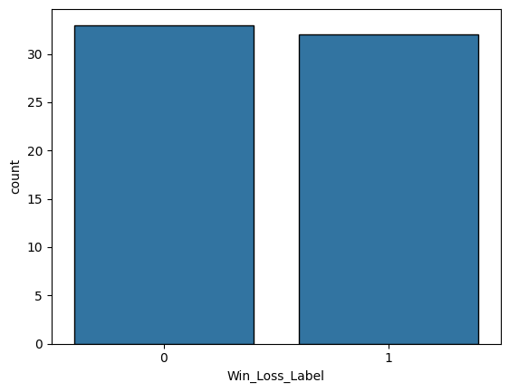

```python
sns.countplot(data=data, x='Win_Loss_Label', edgecolor = "black");
```

```python
print(data['Win_Loss_Label'].value_counts())
```

```
Win_Loss_Label
0    33
1    32
Name: count, dtype: int64
```

```python
pct_label_0 = Y[Y == 0].shape[0] / Y.shape[0]
pct_label_1 = Y[Y == 1].shape[0] / Y.shape[0]
print(f'Percentage of Label 0 (Loss): {round(pct_label_0*100, 2)}. Percentage of Label 1 (Win): {round(pct_label_1*100,2)}') # see cell 78 because unbalanced
```

```
Percentage of Label 0 (Loss): 50.77. Percentage of Label 1 (Win): 49.23
```

## Model evaluation criterion

The Model Can Make Two Types of Wrong Predictions:

- False Positive (FP): Predicting that a character will win when they actually lose.
- False Negative (FN): Predicting that a character will lose when they actually win.

Which Case is More Important?

- The more critical error is False Negative (FN) because:
  - If the model predicts that a character will lose, but they actually win, it fails to identify strong characters correctly.
  - This is a major issue in battle prediction because missing a strong character could lead to incorrect tournament brackets or rankings.
  - FN means underestimating a fighter's strength, which can negatively affect predictions in battles.

How to Reduce False Negatives?

- The goal is to maximize Recall, ensuring that the model correctly identifies as many winning characters as possible.
- Higher recall means fewer missed wins (False Negatives), leading to better predictions of strong contenders.
- If Recall is high, the model is less likely to underestimate powerful characters.

Key Metric: Recall (Sensitivity / True Positive Rate)

- Use Cases:
  - Important when missing a winning character is more critical.
  - Ensures that strong characters are correctly classified as winners.
  - Useful when identifying battle outcomes where underestimating a fighter’s strength could lead to poor predictions.

Create a function to calculate and print the classification report and the confusion matrix so that we don't have to rewrite the same code repeatedly for each model.

```python
# Creating metric function

def metrics_score(actual, predicted):

    print(classification_report(actual, predicted)) # print classification report (precision, recall, accuracy, etc...)

    cm = confusion_matrix(actual, predicted)

    plt.figure(figsize = (8, 5))

    #sns.heatmap(cm, annot = True, fmt = '.2f', xticklabels = ['Not Attriate', 'Attriate'], yticklabels = ['Not Attriate', 'Attriate'])
    sns.heatmap(cm, annot=True, fmt=".2f", xticklabels=["Loss", "Win"], yticklabels=["Loss", "Win"])
    plt.ylabel('Actual')

    plt.xlabel('Predicted')

    plt.show()
```

```python
def model_performance_classification(model, predictors, target):
    """
    Function to compute different metrics to check classification model performance

    model: classifier

    predictors: independent variables

    target: dependent variable
    """

    # Predicting using the independent variables
    pred = model.predict(predictors)

    recall = recall_score(target, pred,average = 'macro')                 # To compute recall

    precision = precision_score(target, pred, average = 'macro')              # To compute precision

    acc = accuracy_score(target, pred)                                 # To compute accuracy score


    # Creating a dataframe of metrics

    df_perf = pd.DataFrame(
        {
            "Precision":  precision,
            "Recall":  recall,
            "Accuracy": acc,
        },

        index = [0],
    )

    return df_perf
```

## Building the model

- Decision Tree
- Random Forest

### Building a Decision Tree Model

- We will build our model using the DecisionTreeClassifier function.

```python
# # If NOT balanced

# dt_no_weights = DecisionTreeClassifier(random_state = 1)

# dt_weights = DecisionTreeClassifier(class_weight = {0: 0.49, 1: 0.51}, random_state = 1) # to give more importance to the class with the lowest percentage
# # class weight (hyperparameter) is useful when dealing with unbalanced/imbalanced data: see cell 74 above (sns.countplot(data=df, x='Attrition', edgecolor = 'black')

# # cell 50: Percentage of Label 0 (Not Attriate): 83.88. Percentage of Label 1 (Attritiate): 16.12 = 0.83 given to class with lowest percentage = class 1 !!!!!!!!!!!
#   # flipped/inversed it
#   # for unbalanced/imbalanced data
#   # can be optimized but instructor stated better to get form distribution (cell 74)
```

```python
# # Fitting decision tree model
# dt_no_weights.fit(x_train, y_train)
```

```python
# Fitting decision tree model
# dt_weights.fit(x_train, y_train)
```

```python
from sklearn.tree import DecisionTreeClassifier

# Fitting decision tree model
dt.fit(x_train, y_train)
```

```
DecisionTreeClassifier(random_state=1)
```

Let's check the model performance of decision tree

```python
from sklearn.metrics import classification_report, confusion_matrix

# Checking performance on the training dataset
y_train_pred_dt = dt.predict(x_train)

metrics_score(y_train, y_train_pred_dt)
```

[output not shown]

```
              precision    recall  f1-score   support

           0       1.00      1.00      1.00        26
           1       1.00      1.00      1.00        26

    accuracy                           1.00        52
   macro avg       1.00      1.00      1.00        52
weighted avg       1.00      1.00      1.00        52
```

```python
# Checking performance on the test dataset
y_test_pred_dt = dt.predict(x_test)

metrics_score(y_test, y_test_pred_dt)
```

[output not shown]

```
              precision    recall  f1-score   support

           0       1.00      1.00      1.00         7
           1       1.00      1.00      1.00         6

    accuracy                           1.00        13
   macro avg       1.00      1.00      1.00        13
weighted avg       1.00      1.00      1.00        13
```

## Observations

```python
# performance_classification with training data

model_performance_classification(dt, x_train, y_train)
```

|  | Precision | Recall | Accuracy |
| --- | --- | --- | --- |
| 0 | 1.0 | 1.0 | 1.0 |

```python
# dtree_test = model_performance_classification(dt,x_test,y_test)
dtree_test = model_performance_classification(dt,x_test,y_test)
dtree_test
```

|  | Precision | Recall | Accuracy |
| --- | --- | --- | --- |
| 0 | 1.0 | 1.0 | 1.0 |

- Observations
  - Training Performance: The decision tree model achieved 100% accuracy on the training set, with perfect precision, recall, and F1-score across both classes. This indicates the model has memorized the training data completely.
  - Testing Performance: The model also performed perfectly on the test set, achieving 100% precision, recall, and F1-score. This suggests no misclassifications occurred.
  - Potential Overfitting: Normally, a model should exhibit slight performance degradation on unseen data. Since both train and test sets have 100% accuracy, it indicates a potential case of overfitting, though this is unlikely given the balanced dataset.
  - Dataset Balance Impact: The dataset is balanced (nearly equal wins and losses), which removes concerns of bias towards a dominant class.

plot the feature importance and check the most important features

```python
importances = dt.feature_importances_
importances
```

```
array([1., 0., 0., 0., 0., 0., 0., 0., 0., 0., 0., 0., 0., 0., 0., 0., 0.,
       0., 0., 0., 0., 0., 0., 0., 0., 0., 0., 0., 0., 0., 0., 0., 0., 0.,
       0., 0., 0., 0., 0., 0., 0., 0., 0., 0., 0., 0., 0., 0., 0., 0., 0.,
       0., 0., 0., 0., 0., 0., 0., 0., 0., 0., 0., 0., 0., 0., 0., 0., 0.,
       0., 0., 0., 0., 0., 0., 0., 0., 0., 0., 0., 0., 0., 0., 0., 0., 0.,
       0., 0., 0., 0., 0., 0., 0., 0., 0., 0., 0., 0., 0., 0., 0., 0., 0.,
       0., 0., 0., 0., 0., 0., 0., 0., 0., 0., 0., 0., 0., 0., 0., 0., 0.,
       0., 0., 0., 0., 0., 0., 0., 0., 0., 0., 0., 0.])
```

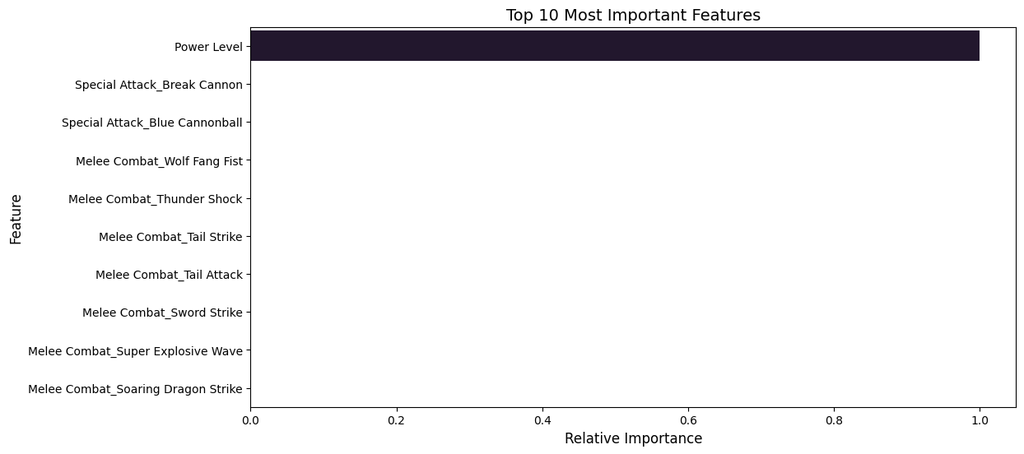

```python
# Create DataFrame
importance_df = pd.DataFrame(importances, index=columns, columns=['Importance'])

# Sort values and get top 10
importance_df = importance_df.sort_values(by='Importance', ascending=False).head(10)

# Plot the feature importances
plt.figure(figsize=(12, 6))
sns.barplot(x=importance_df.Importance, y=importance_df.index, palette='rocket')
plt.title("Top 10 Most Important Features", fontsize=14)
plt.xlabel("Relative Importance", fontsize=12)
plt.ylabel("Feature", fontsize=12)
plt.show()
```

### Tuning the Decision Tree Classifier using GridSearch

- Hyperparameter tuning is tricky in the sense that there is no direct way to calculate how a change in the hyperparameter value will reduce the loss of your model, so we usually resort to experimentation. We'll use Grid search to perform hyperparameter tuning.
- Grid search is a tuning technique that attempts to compute the optimum values of hyperparameters.
- It is an exhaustive search that is performed on the specific parameter values of a model. The parameters of the estimator/model used to apply these methods are optimized by cross-validated grid-search over a parameter grid.
- Criterion{“gini”, “entropy”}
  - The function is to measure the quality of a split. Supported criteria are “gini” for the Gini impurity and “entropy” for the information gain.
- max_depth
  - The maximum depth of the tree. If None, then nodes are expanded until all leaves are pure or until all leaves contain less than min_samples_split samples.
- min_samples_leaf
  - The minimum number of samples is required to be at a leaf node. A split point at any depth will only be considered if it leaves at least min_samples_leaf training samples in each of the left and right branches. This may have the effect of smoothing the model, especially in regression.

```python
from sklearn.metrics import classification_report, confusion_matrix, recall_score
from sklearn.model_selection import GridSearchCV

#%%time
# Choose the type of classifier
dtree_tuned = DecisionTreeClassifier(random_state = 1)

# Grid of parameters to choose from
parameters = {'max_depth': np.arange(2, 7), # should test a wide range of values 2, 15, 50, 100
              'criterion': ['gini', 'entropy'],
              'min_samples_leaf': [5, 10, 20, 25]}

# Type of scoring used to compare parameter combinations.
# "pos_label": It allows you to specify which class label should be considered as the positive class when calculating the scoring metric.
# By default, pos_label = 1, but you can change it based on your specific use case.
scorer = metrics.make_scorer(recall_score, pos_label = 1)

# Grid search object
gridCV = GridSearchCV(dtree_tuned, parameters, scoring = scorer, cv = 10) # cross validation, GridSearchCV to tune hyperparameters

# Fitting the grid search on the train data
gridCV = gridCV.fit(x_train, y_train)

# Set the classifier to the best combination of parameters
dtree_tuned = gridCV.best_estimator_

# Fit the best estimator to the data
dtree_tuned.fit(x_train, y_train)
```

```
DecisionTreeClassifier(max_depth=2, min_samples_leaf=5, random_state=1)
```

```python
# Show attributes in the object
gridCV.best_estimator_.__dict__
```

```
{'criterion': 'gini',
 'splitter': 'best',
 'max_depth': 2,
 'min_samples_split': 2,
 'min_samples_leaf': 5,
 'min_weight_fraction_leaf': 0.0,
 'max_features': None,
 'max_leaf_nodes': None,
 'random_state': 1,
 'min_impurity_decrease': 0.0,
 'class_weight': None,
 'ccp_alpha': 0.0,
 'monotonic_cst': None,
 'feature_names_in_': array(['Power Level', 'Speed', 'Transformation_Level', 'Race_Android',
        'Race_Angel', 'Race_Bio-Android', 'Race_Demon', 'Race_Frost Demon',
        'Race_Genie', 'Race_Grasshopper', 'Race_Half-Saiyan', 'Race_Human',
        'Race_Kai', 'Race_Majin', 'Race_Monkey', 'Race_Namekian',
        'Race_Saiyan', 'Race_Shape-shifter', 'Race_Wizard',
        'Ki Blast_Bomber DX', 'Ki Blast_Bunkai Teleport',
        'Ki Blast_Burning Attack', 'Ki Blast_Darkness Eye Beam',
        'Ki Blast_Death Beam', 'Ki Blast_Destruction',
        'Ki Blast_Destructo Disc', 'Ki Blast_Dodon Ray',
        'Ki Blast_Dodoria Beam', 'Ki Blast_Double Sunday',
        'Ki Blast_Elegant Blaster', 'Ki Blast_Energy Blast',
        'Ki Blast_Energy Drain', 'Ki Blast_Energy Wave',
        'Ki Blast_Eraser Cannon', 'Ki Blast_Evil Flame',
        'Ki Blast_Explosive Demon Wave', 'Ki Blast_Eye Beam',
        'Ki Blast_Final Explosion', 'Ki Blast_Galactic Buster',
        'Ki Blast_Galick Gun', 'Ki Blast_Guldo Psychic Move',
        "Ki Blast_Hell's Flash", 'Ki Blast_Justice Beam',
        'Ki Blast_Kamehameha', 'Ki Blast_Masenko', 'Ki Blast_Milky Cannon',
        'Ki Blast_Mind Control', 'Ki Blast_Power Blitz',
        'Ki Blast_Recoome Eraser Gun', 'Ki Blast_S.S. Deadly Bomber',
        'Ki Blast_Special Beam Cannon', 'Ki Blast_Spinning Blade',
        'Ki Blast_Spirit Ball', 'Ki Blast_Staff Strike',
        'Ki Blast_Supernova Cooler', 'Ki Blast_Tri-Beam',
        'Ki Blast_Vanishing Ball', 'Melee Combat_Angelic Martial Arts',
        'Melee Combat_Arm Break', 'Melee Combat_Axe Handle Smash',
        'Melee Combat_Babidi Curse', 'Melee Combat_Big Bang',
        'Melee Combat_Big Bang Attack', 'Melee Combat_Blue Tornado',
```

[output cut: 29 more lines]

```
        'Special Attack_Monster Crush', 'Special Attack_Mouth Energy Wave',
        'Special Attack_Non-Stop Violence', 'Special Attack_Omega Blaster',
        'Special Attack_Psychic Powers',
        'Special Attack_Recoome Ultra Fighting Bomber',
        'Special Attack_Saiyan Man Pose', 'Special Attack_Saturday Crush',
        'Special Attack_Solar Flare', 'Special Attack_Solar Kamehameha',
        'Special Attack_Spirit Bomb', 'Special Attack_Stone Spit',
        'Special Attack_Supernova', 'Special Attack_Temporal Do-Over',
        'Special Attack_Wolf Fang Fist'], dtype=object),
 'n_features_in_': 131,
 'n_outputs_': 1,
 'classes_': array([0, 1]),
 'n_classes_': 2,
 'max_features_': 131,
 'tree_': <sklearn.tree._tree.Tree at 0x7ec3bcf52100>}
```

```python
# Checking performance on the TRAINING DATASET
y_train_pred_dt = dtree_tuned.predict(x_train)

metrics_score(y_train, y_train_pred_dt)
```

[output not shown]

```
              precision    recall  f1-score   support

           0       1.00      1.00      1.00        26
           1       1.00      1.00      1.00        26

    accuracy                           1.00        52
   macro avg       1.00      1.00      1.00        52
weighted avg       1.00      1.00      1.00        52
```

```python
# Checking performance on the TEST SET
y_test_pred_dt = dtree_tuned.predict(x_test)

metrics_score(y_test, y_test_pred_dt)
```

[output not shown]

```
              precision    recall  f1-score   support

           0       1.00      1.00      1.00         7
           1       1.00      1.00      1.00         6

    accuracy                           1.00        13
   macro avg       1.00      1.00      1.00        13
weighted avg       1.00      1.00      1.00        13
```

- Observations
  - Perfect test performance: The model achieved 100% precision, recall, and F1-score on the test set.
  - No misclassifications: Every win and loss was correctly predicted.
  - Potential overfitting: Matching training performance suggests the model may have memorized patterns instead of generalizing.
- Recall Summary
  - Recall remains 1.00 on the test set, meaning no false negatives.
  - If the dataset is small, this could indicate data leakage or insufficient complexity in real-world scenarios.

```python
from sklearn.metrics import precision_score, recall_score, f1_score, accuracy_score

# TEST DATA
dtree_tuned_test = model_performance_classification(dtree_tuned,x_test,y_test)
dtree_tuned_test
```

|  | Precision | Recall | Accuracy |
| --- | --- | --- | --- |
| 0 | 1.0 | 1.0 | 1.0 |

Output metrics BEFORE tuning the model

```python
temp = pd.concat([model_performance_classification(dt, x_train, y_train),
                  model_performance_classification(dt, x_test, y_test)], axis=0)

temp.index = ['Training dataset', 'Test dataset']

temp
```

|  | Precision | Recall | Accuracy |
| --- | --- | --- | --- |
| Training dataset | 1.0 | 1.0 | 1.0 |
| Test dataset | 1.0 | 1.0 | 1.0 |

```python
temp = pd.concat([model_performance_classification(dtree_tuned, x_train, y_train),
                  model_performance_classification(dtree_tuned, x_test, y_test)], axis=0)

temp.index = ['Training dataset', 'Test dataset']

temp
```

|  | Precision | Recall | Accuracy |
| --- | --- | --- | --- |
| Training dataset | 1.0 | 1.0 | 1.0 |
| Test dataset | 1.0 | 1.0 | 1.0 |

- Observations
  - The Decision Tree model shows a perfect score of 1.0 across Precision, Recall, and Accuracy for both Training and Test datasets.
  - Such high scores suggest potential overfitting, where the model memorizes the training data and lacks generalization.
  - Since the model performs equally well on both datasets, it indicates that the dataset might be easily separable or lacks complexity.
- Recall Assessment:
  - Recall is 1.0, meaning the model correctly identifies all positive cases (winning battles) without missing any.
  - This is ideal when minimizing false negatives is crucial (e.g., ensuring all strong fighters are correctly classified).
  - However, perfect recall along with perfect precision and accuracy suggests an over-simplified decision boundary, potentially reducing real-world robustness.

Let's look at the feature importance of this model and try to analyze why this is happening.

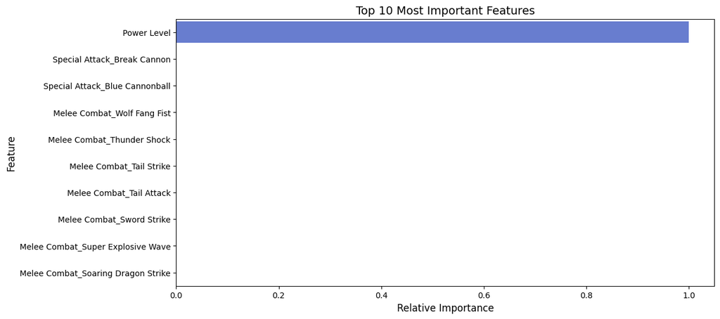

```python
# Feature importance extraction
importances = dtree_tuned.feature_importances_
#columns = x.columns

# Create DataFrame and get top 10 features
importance_df = pd.DataFrame(importances, index=columns, columns=['Importance'])
importance_df = importance_df.sort_values(by='Importance', ascending=False).head(10)

# Plot top 10 feature importances
plt.figure(figsize=(12, 6))
sns.barplot(x=importance_df.Importance, y=importance_df.index, palette="coolwarm")
plt.title("Top 10 Most Important Features", fontsize=14)
plt.xlabel("Relative Importance", fontsize=12)
plt.ylabel("Feature", fontsize=12)
plt.show()
```

- Observations
  - "Power Level" is the most dominant feature – It has the highest importance, indicating that it plays a critical role in determining battle outcomes.

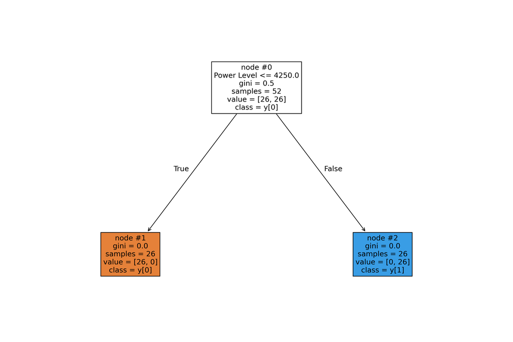

```python
from sklearn import tree

features = list(X.columns)

plt.figure(figsize = (15, 10), dpi=300)

# "node_ids": Show the ID number on each node.
# "class_names": Names of each of the target classes in ascending numerical order
tree.plot_tree(dt, max_depth = 2, feature_names = features, filled = True, fontsize = 12, node_ids = True, class_names = True)

plt.show()
```

```python
# Number of training samples
x_train.shape[0]
```

```
52
```

```python
# Number of samples of label 0 (No attrition)
y_train[y_train == 0].shape[0]
```

```
26
```

```python
# Number of samples of label 1 (Attrition)
y_train[y_train == 1].shape[0]
```

```
26
```

Decision Tree and Tuned

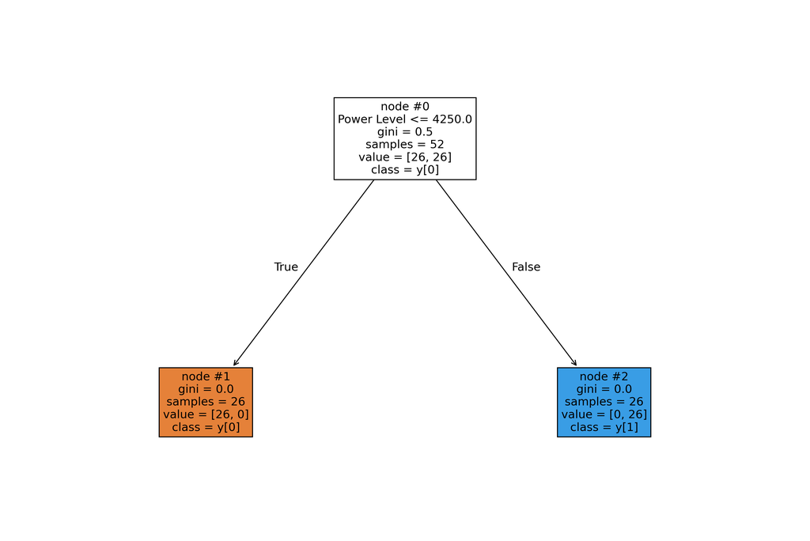

```python
features = list(X.columns)

plt.figure(figsize = (15, 10), dpi=300)

tree.plot_tree(dtree_tuned, max_depth = 4, feature_names = features, filled = True, fontsize = 12, node_ids = True, class_names = True)

plt.show()
```

### Random Forest

- Building the Random Forest Classifier
- Random Forest is a bagging algorithm where the base models are Decision Trees. Samples are taken from the training data and on each sample, a decision tree makes a prediction.
- The results from all the decision trees are combined and the final prediction is made using voting (for classification problems) or averaging (for regression problems).

```python
from sklearn.ensemble import RandomForestClassifier

# Fitting the Random Forest classifier on the training data
rf_estimator = RandomForestClassifier(random_state = 1)

rf_estimator.fit(x_train, y_train)
```

```
RandomForestClassifier(random_state=1)
```

```python
# Checking performance on the training data
y_pred_train_rf = rf_estimator.predict(x_train)

metrics_score(y_train, y_pred_train_rf)
```

[output not shown]

```
              precision    recall  f1-score   support

           0       1.00      1.00      1.00        26
           1       1.00      1.00      1.00        26

    accuracy                           1.00        52
   macro avg       1.00      1.00      1.00        52
weighted avg       1.00      1.00      1.00        52
```

```python
# Checking performance on the testing data
y_pred_test_rf = rf_estimator.predict(x_test)

metrics_score(y_test, y_pred_test_rf)
```

[output not shown]

```
              precision    recall  f1-score   support

           0       1.00      1.00      1.00         7
           1       1.00      1.00      1.00         6

    accuracy                           1.00        13
   macro avg       1.00      1.00      1.00        13
weighted avg       1.00      1.00      1.00        13
```

```python
# Checking performance on the TRAINING SET
model_performance_classification(rf_estimator, x_train, y_train)
```

|  | Precision | Recall | Accuracy |
| --- | --- | --- | --- |
| 0 | 1.0 | 1.0 | 1.0 |

```python
# Checking performance on the TEST SET
rf_estimator_test = model_performance_classification(rf_estimator,x_test,y_test)
rf_estimator_test
```

|  | Precision | Recall | Accuracy |
| --- | --- | --- | --- |
| 0 | 1.0 | 1.0 | 1.0 |

- Observations
  - Perfect Classification Performance
    - The model achieves 100% precision, recall, and accuracy on both the training and test sets.
    - This suggests that every instance has been correctly classified without any false positives or false negatives.
  - Potential Overfitting Concern
    - While achieving perfect scores is desirable, it could indicate that the model is memorizing the training data rather than generalizing well.
    - Overfitting typically occurs when the model is too complex for the dataset and learns patterns too specifically.
  - Possible Reasons for Perfect Scores
    - The dataset might be too small or too easy to classify, making perfect predictions possible.
    - The features used may have strong predictive power (e.g., "Power Level" being a dominant feature in Dragon Ball battles).
    - The train-test split may not be diverse enough, leading to similar distributions in both sets.

feature importance of the Random Forest

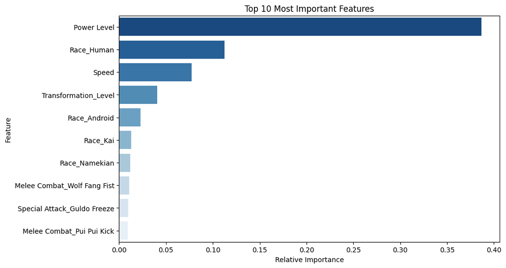

```python
importances = rf_estimator.feature_importances_
columns = X.columns

importance_df = pd.DataFrame(importances, index=columns, columns=['Importance'])
importance_df = importance_df.sort_values(by='Importance', ascending=False).head(10)  # Select top 10

plt.figure(figsize=(10, 6))  # Adjust figure size
sns.barplot(x=importance_df.Importance, y=importance_df.index, palette="Blues_r")
plt.xlabel("Relative Importance")
plt.ylabel("Feature")
plt.title("Top 10 Most Important Features")
plt.show()
```

### Tuning the Random Forest classifier using GridSearch

- n_estimators: The number of trees in the forest.
- min_samples_split: The minimum number of samples required to split an internal node.
- min_samples_leaf: The minimum number of samples required to be at a leaf node.
- max_features{“auto”, “sqrt”, “log2”, 'None'}: The number of features to consider when looking for the best split.
  - If “auto”, then max_features=sqrt(n_features).
  - If “sqrt”, then max_features=sqrt(n_features) (same as “auto”).
  - If “log2”, then max_features=log2(n_features).
  - If None, then max_features=n_features.

```python
%%time
# Choose the type of classifier
rf_estimator_tuned = RandomForestClassifier(random_state = 1)

# Grid of parameters to choose from
params_rf = {"n_estimators": [100, 250, 500],
             "min_samples_leaf": np.arange(1, 4, 1),
             "max_features": [0.7, 0.9, 'auto']} # max features: number of features to randomly select from data set (.7 is 70% of features to 90%)

# Type of scoring used to compare parameter combinations - recall score for class 1
scorer = metrics.make_scorer(recall_score, pos_label = 1)

# Run the grid search
grid_obj = GridSearchCV(rf_estimator_tuned, params_rf, scoring = scorer, cv = 5)

grid_obj = grid_obj.fit(x_train, y_train)

# Set the classifier to the best combination of parameters
rf_estimator_tuned = grid_obj.best_estimator_
```

```
CPU times: user 46.9 s, sys: 125 ms, total: 47 s
Wall time: 49.2 s
```

```python
rf_estimator_tuned.fit(x_train, y_train)
```

```
RandomForestClassifier(max_features=0.7, random_state=1)
```

```python
# Checking performance on the training data
y_pred_train_rf_tuned = rf_estimator_tuned.predict(x_train)

metrics_score(y_train, y_pred_train_rf_tuned)
```

[output not shown]

```
              precision    recall  f1-score   support

           0       1.00      1.00      1.00        26
           1       1.00      1.00      1.00        26

    accuracy                           1.00        52
   macro avg       1.00      1.00      1.00        52
weighted avg       1.00      1.00      1.00        52
```

```python
# Checking performance on the test data
y_pred_test_rf_tuned = rf_estimator_tuned.predict(x_test)

metrics_score(y_test, y_pred_test_rf_tuned)
```

[output not shown]

```
              precision    recall  f1-score   support

           0       1.00      1.00      1.00         7
           1       1.00      1.00      1.00         6

    accuracy                           1.00        13
   macro avg       1.00      1.00      1.00        13
weighted avg       1.00      1.00      1.00        13
```

```python
# Checking performance on the TRAINING SET
model_performance_classification(rf_estimator_tuned, x_train, y_train)
```

|  | Precision | Recall | Accuracy |
| --- | --- | --- | --- |
| 0 | 1.0 | 1.0 | 1.0 |

```python
# Checking performance on the TEST SET
rf_estimator_tuned_test = model_performance_classification(rf_estimator_tuned, x_test, y_test)
rf_estimator_tuned_test
```

|  | Precision | Recall | Accuracy |
| --- | --- | --- | --- |
| 0 | 1.0 | 1.0 | 1.0 |

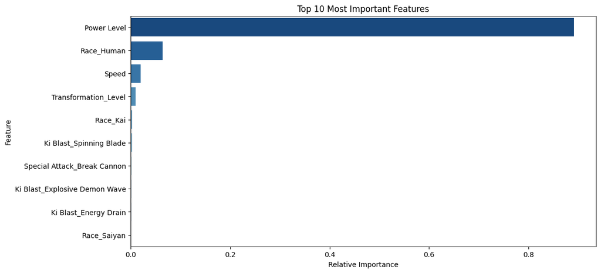

```python
importances = rf_estimator_tuned.feature_importances_
columns = X.columns

# Convert to DataFrame and get top 10 features
importance_df = pd.DataFrame(importances, index=columns, columns=['Importance']).sort_values(by='Importance', ascending=False).head(10)

# Plot
plt.figure(figsize=(12, 6))  # Adjust figure size
sns.barplot(x=importance_df.Importance, y=importance_df.index, palette="Blues_r")

# Labels and title
plt.xlabel("Relative Importance")
plt.ylabel("Feature")
plt.title("Top 10 Most Important Features")

plt.show()
```

## Boosting Models

XGBoost

- XGBoost stands for Extreme Gradient Boosting.
- XGBoost is a tree-based ensemble machine learning technique that improves prediction power and performance by improvising on the Gradient Boosting framework and incorporating reliable approximation algorithms. It is widely utilized and routinely appears at the top of competition leader boards in data science.

```python
# Installing the xgboost library using the 'pip' command.
!pip install xgboost
```

```python
# Importing the AdaBoostClassifier and GradientBoostingClassifier [Boosting]
from sklearn.ensemble import AdaBoostClassifier, GradientBoostingClassifier

# Importing the XGBClassifier from the xgboost library
from xgboost import XGBClassifier
```

```python
# Adaboost Classifier
adaboost_model = AdaBoostClassifier(random_state = 1)

# Fitting the model
adaboost_model.fit(x_train, y_train)

# Model Performance on the test data
adaboost_model_perf_test = model_performance_classification(adaboost_model,x_test,y_test)

adaboost_model_perf_test
```

|  | Precision | Recall | Accuracy |
| --- | --- | --- | --- |
| 0 | 1.0 | 1.0 | 1.0 |

```python
# Gradient Boost Classifier
gbc = GradientBoostingClassifier(random_state = 1)

# Fitting the model
gbc.fit(x_train, y_train)

# Model Performance on the test data
gbc_perf_test = model_performance_classification(gbc, x_test, y_test)

gbc_perf_test
```

|  | Precision | Recall | Accuracy |
| --- | --- | --- | --- |
| 0 | 1.0 | 1.0 | 1.0 |

Model Performance Comparison

Evaluation Metrics

| Model | Dataset | Precision | Recall | F1-Score | Accuracy |
| --- | --- | --- | --- | --- | --- |
| Decision Tree | Train | 1.00 | 1.00 | 1.00 | 1.00 |
| Decision Tree | Test | 1.00 | 1.00 | 1.00 | 1.00 |
| Random Forest | Train | 1.00 | 1.00 | 1.00 | 1.00 |
| Random Forest | Test | 1.00 | 1.00 | 1.00 | 1.00 |
| Tuned Random Forest | Train | 1.00 | 1.00 | 1.00 | 1.00 |
| Tuned Random Forest | Test | 1.00 | 1.00 | 1.00 | 1.00 |

Observations

Ranking of Models (Equal Performance)

1. **Decision Tree** - Simple, interpretable, and fast.
2. **Random Forest** - More robust, avoids overfitting, but unnecessary in this case.
3. **Tuned Random Forest** - Added complexity without performance gains.

Conclusion: Since all models performed identically, model selection depends on computational efficiency and interpretability. The Decision Tree is preferable due to its simplicity unless additional complexity is required for future dataset variations.

```python
import xgboost as xgb

# Convert Pandas DataFrame to NumPy array
x_train = x_train.values
y_train = y_train.values
x_test = x_test.values
y_test = y_test.values

# Initialize XGBoost Classifier
xgb_model = xgb.XGBClassifier(random_state=1, eval_metric='logloss')

# Fit the model
xgb_model.fit(x_train, y_train)

# Model Performance on Test Data
xgb_perf_test = model_performance_classification(xgb_model, x_test, y_test)

# Display performance
xgb_perf_test
```

|  | Precision | Recall | Accuracy |
| --- | --- | --- | --- |
| 0 | 1.0 | 1.0 | 1.0 |

## Hyperparameter Tuning: Boosting

Hyperparameter tuning is a great technique in machine learning to develop the model with optimal parameters. If the size of the data increases, the computation time will increase during the training process.

- For practice purposes, we have listed below some of the important hyperparameters for each algorithm that can be tuned to improve the model performance.

Adaboost

- Some important hyperparameters that can be tuned:
  - base_estimator object, default = None The base estimator from which the boosted ensemble is built. Support for sample weighting is required, as well as proper classes_ and n_classes_ attributes. If None, then the base estimator is DecisionTreeClassifier initialized with max_depth=1
  - n_estimators int, default = 50 The maximum number of estimators at which boosting is terminated. In the case of a perfect fit, the learning procedure is stopped early.
  - learning_rate float, default = 1.0 Weight is applied to each classifier at each boosting iteration. A higher learning rate increases the contribution of each classifier.

Gradient Boosting Algorithm

- Some important hyperparameters that can be tuned:
  - n_estimators: The number of boosting stages that will be performed.
  - max_depth: Limits the number of nodes in the tree. The best value depends on the interaction of the input variables.
  - min_samples_split: The minimum number of samples required to split an internal node.
  - learning_rate: How much the contribution of each tree will shrink.
  - loss:Loss function to optimize.

XGBoost Algorithm

- Some important hyperparameters that can be tuned:
  - booster [default = gbtree ] Which booster to use. Can be gbtree, gblinear, or dart; gbtree and dart use tree-based models while gblinear uses linear functions.
  - min_child_weight [default = 1]
    - The minimum sum of instance weight (hessian) needed in a child. If the tree partition step results in a leaf node with the sum of instance weight less than min_child_weight, then the building process will give up further partitioning.The larger min_child_weight is, the more conservative the algorithm will be.

## Comparison of all the models

```python
models_test_comp_df = pd.concat([dtree_test.T,
                                 dtree_tuned_test.T,
                                 rf_estimator_test.T,
                                 rf_estimator_tuned_test.T,
                                 adaboost_model_perf_test.T,
                                 gbc_perf_test.T,
                                 xgb_perf_test.T], axis = 1)

models_test_comp_df.columns = ["Decision Tree classifier",
                               "Tuned Decision Tree classifier",
                               "Random Forest classifier",
                               "Tuned Random Forest classifier",
                               "Adaboost classifier",
                               "Gradientboost classifier",
                               "XGBoost classifier"]

print("Test performance comparison:")
```

```
Test performance comparison:
```

```python
models_test_comp_df
```

|  | Decision Tree classifier | Tuned Decision Tree classifier | Random Forest classifier | Tuned Random Forest classifier | Adaboost classifier | Gradientboost classifier | XGBoost classifier |
| --- | --- | --- | --- | --- | --- | --- | --- |
| Precision | 1.0 | 1.0 | 1.0 | 1.0 | 1.0 | 1.0 | 1.0 |
| Recall | 1.0 | 1.0 | 1.0 | 1.0 | 1.0 | 1.0 | 1.0 |
| Accuracy | 1.0 | 1.0 | 1.0 | 1.0 | 1.0 | 1.0 | 1.0 |

- Observation
  - All Models Have Perfect Scores
    - Precision, Recall, and Accuracy are all 1.0 (100%) across every classifier.
    - This suggests that the models are predicting all test cases correctly without errors.
  - Potential Overfitting
    - A perfect score is highly unusual in real-world datasets and may indicate overfitting.
    - Overfitting can occur when a model learns patterns too specifically to the training data and lacks generalization.
  - Possible Data Leakage or Issues
    - If the dataset is too small, the models might be memorizing patterns instead of generalizing.
    - Check for data leakage, such as test data being influenced by training data.
    - Ensure features make sense and there aren’t any duplicated or leaking variables.
  - Balanced Dataset and Simple Patterns?
    - If the dataset is perfectly balanced and contains highly separable features, such perfect scores might be valid.
    - However, real-world classification tasks usually involve some misclassifications.

## Recommendations

- Verify Data Preprocessing: Check if features are correctly formatted and properly scaled. Ensure no data leakage from the target variable.
- Reduce Overfitting: Implement techniques such as regularization, pruning (for decision trees), and hyperparameter tuning.
- Feature Engineering: Reassess feature selection to ensure meaningful input variables are contributing to predictions. Cross-Validation: Use k-fold cross-validation to get a more reliable estimate of model performance. Test on Unseen Data: Evaluate models on a separate validation dataset to ensure generalizability.

```python
# google

path_ipynb = '/content/drive/MyDrive/My DS DA/Dragon Ball Z/7 Supervised Learning Classification with Decision Trees etc.ipynb'
notebook_path = path_ipynb

!jupyter nbconvert --to html "{notebook_path}"

from google.colab import files
path_html = '/content/drive/MyDrive/My DS DA/Dragon Ball Z/7 Supervised Learning Classification with Decision Trees etc.html'

files.download(path_html)
```

```
[NbConvertApp] Converting notebook /content/drive/MyDrive/My DS DA/Dragon Ball Z/7 Supervised Learning Classification with Decision Trees etc.ipynb to html
[NbConvertApp] WARNING | Alternative text is missing on 16 image(s).
[NbConvertApp] Writing 1590164 bytes to /content/drive/MyDrive/My DS DA/Dragon Ball Z/7 Supervised Learning Classification with Decision Trees etc.html
```